# Quarto Computations

[View this project on GitHub](https://github.com/kailynnk/GSB-544.git)

# Palmer Penguins Modeling

Import the Palmer Penguins dataset and print out the first few rows.

Suppose we want to predict `bill_depth_mm` using the other variables in the dataset.

Which variables would we need to **dummify**?

|  | species | island | bill_length_mm | bill_depth_mm | flipper_length_mm | body_mass_g | sex | year |
| --- | --- | --- | --- | --- | --- | --- | --- | --- |
| 0 | Adelie | Torgersen | 39.1 | 18.7 | 181.0 | 3750.0 | male | 2007 |
| 1 | Adelie | Torgersen | 39.5 | 17.4 | 186.0 | 3800.0 | female | 2007 |
| 2 | Adelie | Torgersen | 40.3 | 18.0 | 195.0 | 3250.0 | female | 2007 |
| 3 | Adelie | Torgersen | NaN | NaN | NaN | NaN | NaN | 2007 |
| 4 | Adelie | Torgersen | 36.7 | 19.3 | 193.0 | 3450.0 | female | 2007 |

|  | bill_length_mm | bill_depth_mm | flipper_length_mm | body_mass_g | year | species_Adelie | species_Chinstrap | species_Gentoo | island_Biscoe | island_Dream | island_Torgersen | sex_female | sex_male |
| --- | --- | --- | --- | --- | --- | --- | --- | --- | --- | --- | --- | --- | --- |
| 0 | 39.1 | 18.7 | 181.0 | 3750.0 | 2007 | 1 | 0 | 0 | 0 | 0 | 1 | 0 | 1 |
| 1 | 39.5 | 17.4 | 186.0 | 3800.0 | 2007 | 1 | 0 | 0 | 0 | 0 | 1 | 1 | 0 |
| 2 | 40.3 | 18.0 | 195.0 | 3250.0 | 2007 | 1 | 0 | 0 | 0 | 0 | 1 | 1 | 0 |
| 4 | 36.7 | 19.3 | 193.0 | 3450.0 | 2007 | 1 | 0 | 0 | 0 | 0 | 1 | 1 | 0 |
| 5 | 39.3 | 20.6 | 190.0 | 3650.0 | 2007 | 1 | 0 | 0 | 0 | 0 | 1 | 0 | 1 |

Let’s use `bill_length_mm` to predict `bill_depth_mm`. Prepare your data and fit the following models on the entire dataset:

- Simple linear regression (e.g. straight-line) model
- Quadratic (degree 2 polynomial) model
- Cubic (degree 3 polynomial) model
- Degree 10 polynomial model

Make predictions for each model and plot your fitted models on the scatterplot.

```
(array([-0.08502128]), np.float64(20.885468318532755))
```

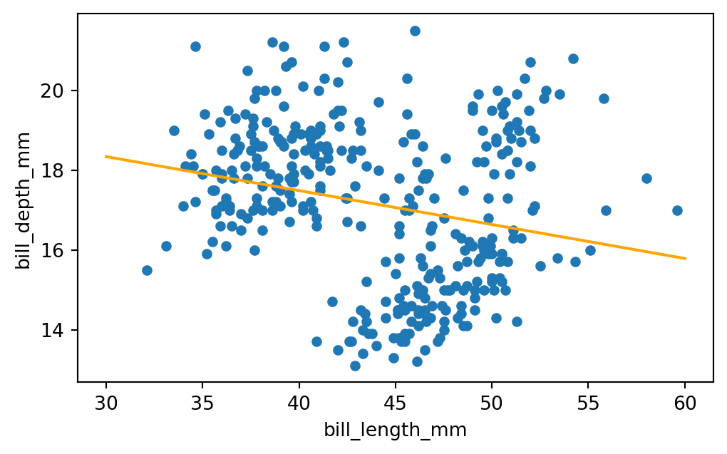

**Quadratic**

|  | bill_length_mm | bill_depth_mm | flipper_length_mm | body_mass_g | year | species_Adelie | species_Chinstrap | species_Gentoo | island_Biscoe | island_Dream | island_Torgersen | sex_female | sex_male | linear_predict | bill_length_mm_squared |
| --- | --- | --- | --- | --- | --- | --- | --- | --- | --- | --- | --- | --- | --- | --- | --- |
| 0 | 39.1 | 18.7 | 181.0 | 3750.0 | 2007 | 1 | 0 | 0 | 0 | 0 | 1 | 0 | 1 | 17.561136 | 1528.81 |
| 1 | 39.5 | 17.4 | 186.0 | 3800.0 | 2007 | 1 | 0 | 0 | 0 | 0 | 1 | 1 | 0 | 17.527128 | 1560.25 |
| 2 | 40.3 | 18.0 | 195.0 | 3250.0 | 2007 | 1 | 0 | 0 | 0 | 0 | 1 | 1 | 0 | 17.459111 | 1624.09 |
| 4 | 36.7 | 19.3 | 193.0 | 3450.0 | 2007 | 1 | 0 | 0 | 0 | 0 | 1 | 1 | 0 | 17.765187 | 1346.89 |
| 5 | 39.3 | 20.6 | 190.0 | 3650.0 | 2007 | 1 | 0 | 0 | 0 | 0 | 1 | 0 | 1 | 17.544132 | 1544.49 |

```
(array([-1.42149289,  0.0151644 ]), np.float64(49.881003221119585))
```

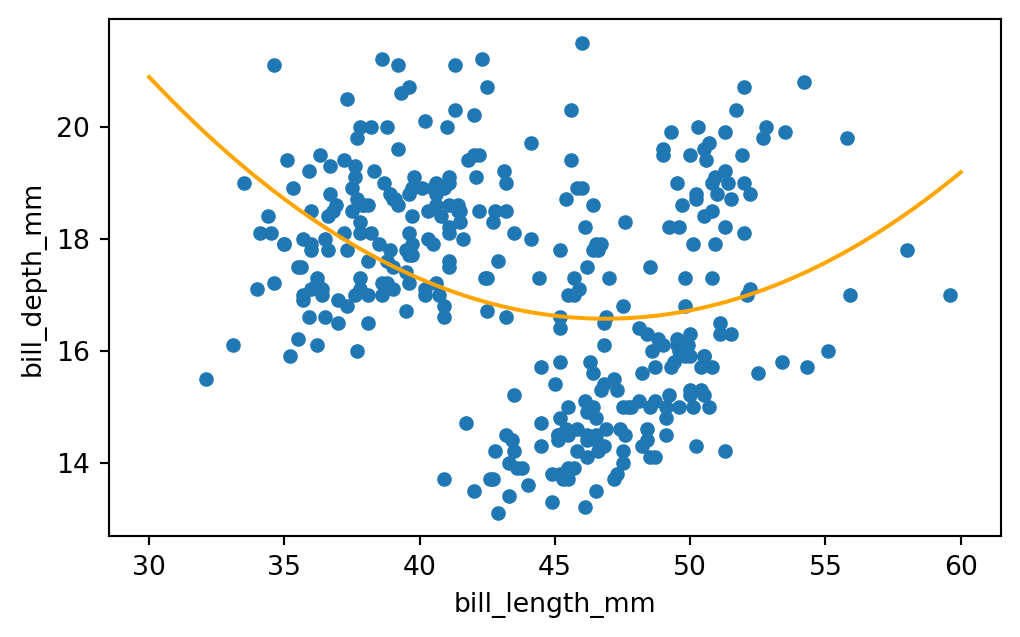

**Cubic**

|  | bill_length_mm | bill_depth_mm | flipper_length_mm | body_mass_g | year | species_Adelie | species_Chinstrap | species_Gentoo | island_Biscoe | island_Dream | island_Torgersen | sex_female | sex_male | linear_predict | bill_length_mm_squared | bill_length_mm_cubed |
| --- | --- | --- | --- | --- | --- | --- | --- | --- | --- | --- | --- | --- | --- | --- | --- | --- |
| 0 | 39.1 | 18.7 | 181.0 | 3750.0 | 2007 | 1 | 0 | 0 | 0 | 0 | 1 | 0 | 1 | 17.561136 | 1528.81 | 59776.471 |
| 1 | 39.5 | 17.4 | 186.0 | 3800.0 | 2007 | 1 | 0 | 0 | 0 | 0 | 1 | 1 | 0 | 17.527128 | 1560.25 | 61629.875 |
| 2 | 40.3 | 18.0 | 195.0 | 3250.0 | 2007 | 1 | 0 | 0 | 0 | 0 | 1 | 1 | 0 | 17.459111 | 1624.09 | 65450.827 |
| 4 | 36.7 | 19.3 | 193.0 | 3450.0 | 2007 | 1 | 0 | 0 | 0 | 0 | 1 | 1 | 0 | 17.765187 | 1346.89 | 49430.863 |
| 5 | 39.3 | 20.6 | 190.0 | 3650.0 | 2007 | 1 | 0 | 0 | 0 | 0 | 1 | 0 | 1 | 17.544132 | 1544.49 | 60698.457 |

```
(array([ 7.00494111e+00, -1.74355549e-01,  1.40554271e-03]),
 np.float64(-73.5917850489481))
```

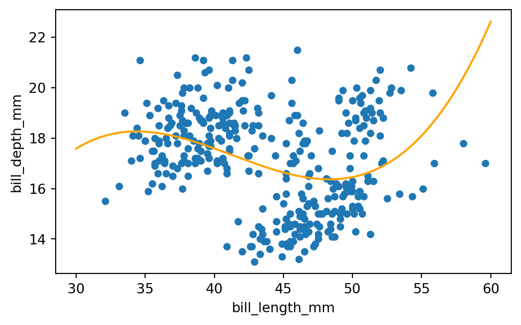

**Degree 10 Polynomial**

```
(342, 11)
```

```
(array([ 0.00000000e+00,  2.59258346e-13,  4.57018313e-12,  1.54316185e-10,
         3.99369189e-09,  7.58162706e-08,  8.32820273e-07, -5.95935634e-08,
         1.61049202e-09, -1.94392298e-11,  8.82283808e-14]),
 np.float64(-20.898873599635767))
```

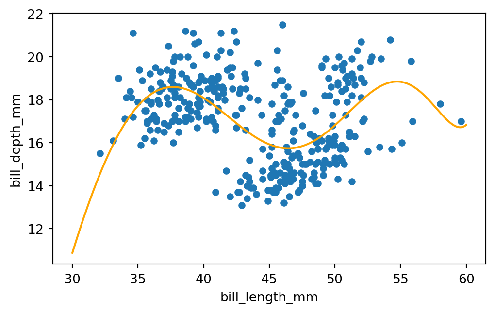

**Are any of the models above underfitting the data? If so, which ones and how can you tell?**

The linear and quadratic model seem to be underfitting the data. It doesn’t really seem to capture the true pattern or have a general idea about the direction of the data.

**Are any of thhe models above overfitting the data? If so, which ones and how can you tell?**

The degree 10 polynomial seems to be a little bit more overfitting since it completely mimics/follows the exact pattern of the training data.

**Which of the above models do you think fits the data best and why?**

The cubic model seems to be the best one because it doesn’t completely mimic the training data but it also looks like it captures its general pattern.